# Spatiotemporal dependence 101

Edzer Pebesma

11/27/2020

## Statistical dependence

What does dependence mean? Roughly: for the state of something (A) we need (the state of) something else (B). Like, in case of financial dependence: “in order to exist (A), I need your money (B)”.

In statistics (or probability theory), two random variables A and B are *independent* if $Pr(A|B)=Pr(A)$, that is, if the conditional probability distribution of $A$ *given* $B$ equals the probability distribution of $A$ without knowing $B$. See [here](https://en.wikipedia.org/wiki/Conditional_probability) for a refresher on conditional probability. If this is not the case, that is if $Pr(A|B) \neq Pr(A)$, we say that $A$ and $B$ are dependent.

## A regression example.

Consider the following simple example:

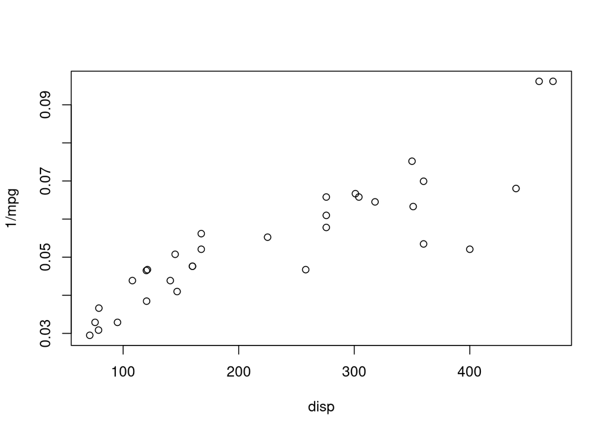

```r
plot(1/mpg~disp, mtcars)
```

which clearly demonstrates that fuel consumption and displacement are related. We could say they are dependent (leaving in the middle whether displacement *causes* fuel consumption, or vice versa).

We can compute *linear* correlation e.g. by

```r
with(mtcars,  cor(1/mpg,disp))
```

```
## [1] 0.8798217
```

which indicates there is a quite strong positive correlation: correlations range between -1 and 1, with 1 (-1) indicating a perfect linear ascending (descending) relationship, and 0 no linear relationship (which does not imply: no relationship).

If we are interested in correlation, we can leave it here. If we’re interested in predicting fuel usages for a new car for which we only know the displacement, we’d use linear regression:

```r
summary(lm(1/mpg~disp, mtcars))
```

```
##
## Call:
## lm(formula = 1/mpg ~ disp, data = mtcars)
##
## Residuals:
##       Min        1Q    Median        3Q       Max
## -0.021881 -0.003825  0.001061  0.005191  0.015194
##
## Coefficients:
##              Estimate Std. Error t value Pr(>|t|)
## (Intercept) 0.0273265  0.0030013   9.105 3.88e-10 ***
## disp        0.0001166  0.0000115  10.139 3.32e-11 ***
## ---
## Signif. codes:  0 '***' 0.001 '**' 0.01 '*' 0.05 '.' 0.1 ' ' 1
##
## Residual standard error: 0.007936 on 30 degrees of freedom
## Multiple R-squared:  0.7741, Adjusted R-squared:  0.7666
## F-statistic: 102.8 on 1 and 30 DF,  p-value: 3.316e-11
```

and could use the regression line as predictor:

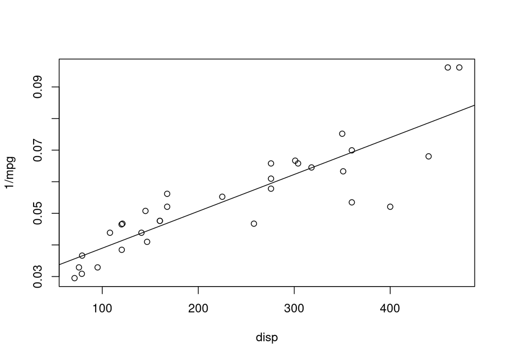

```r
plot(1/mpg~disp, mtcars)
abline(lm(1/mpg~disp, mtcars))
```

We could wonder whether, after taking into account the variability explained by `disp`, regression residuals of this model are still correlated with `disp`. It turns out the aren’t:

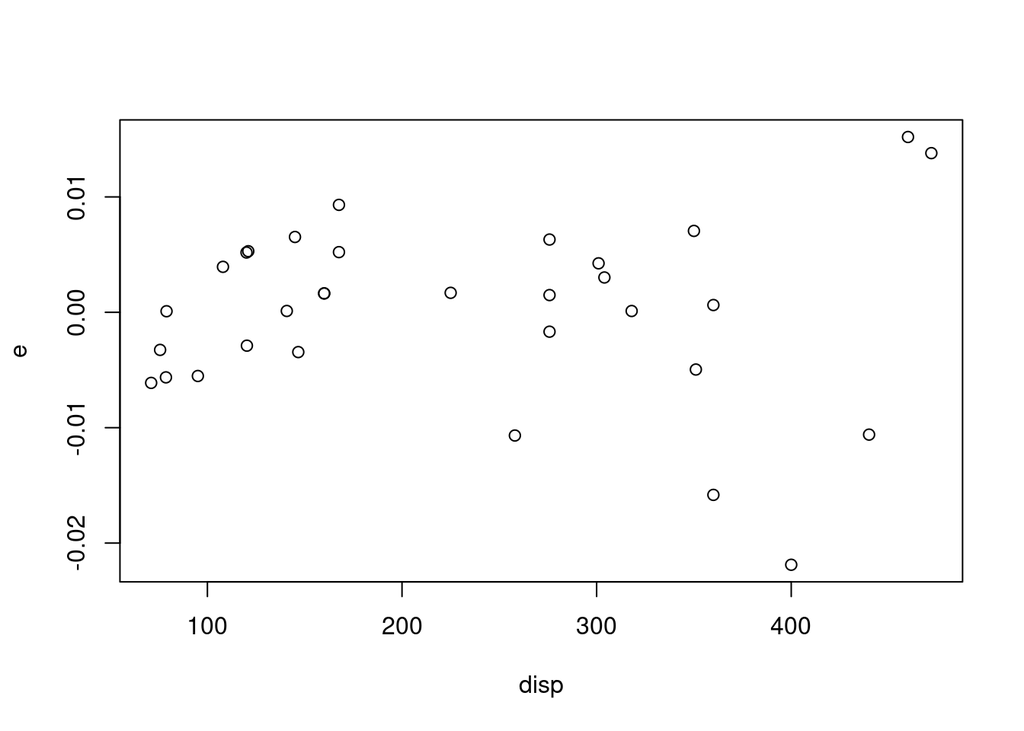

```r
e = residuals(lm(1/mpg~disp, mtcars))
plot(e~disp, mtcars)
```

```r
with(mtcars, cor(e, disp))
```

```
## [1] 2.298823e-17
```

This number is *numerically* identical to zero, and not by coincidence: had there been a non-zero correlation, then we *could* have improved the regression model to pick this up (meaning the regression model we got would not have been the best possible linear fit).

So we see here:

- when two variables are linearly correlated, this can be expressed by computing their correlation coefficient,
- if we model the relationship with linear regression, the regression residuals are uncorrelated (*linearly* independent) from the predictor, by construction

If this is the case, can we say now that residuals are *independent* from $X$? Independence implies zero (linear) correlation, but the reverse is not true. Independence means that $Pr(e|X) = Pr(e)$; zero correlation merely implies $\mbox{Cov}(e,X)=0$. Of course we don’t know $Pr(e|X)$, but we can look at other things.

## Constant variance

$Pr(e|X)=Pr(e)$ implies that the variance of $e$ is not dependent on e. Is it? We can look at variance e.g. by plotting squared or absolute residuals against X:

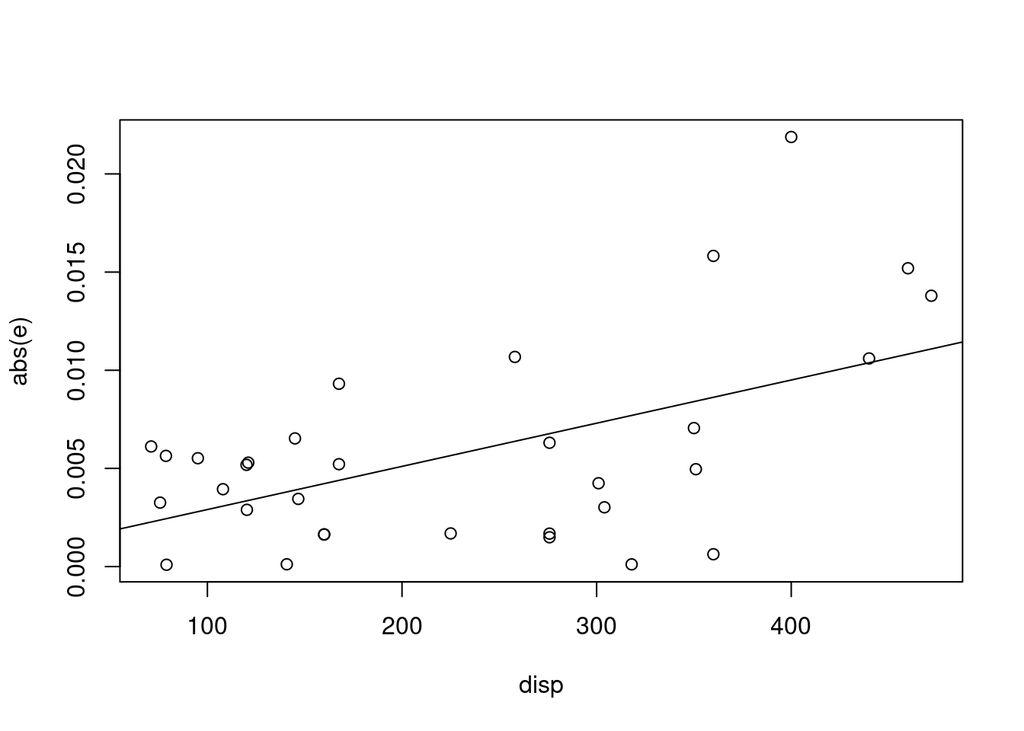

```r
plot(abs(e)~disp, mtcars)
abline(lm(abs(e)~disp,mtcars))
```

```r
summary(lm(abs(e)~disp, mtcars))
```

```
##
## Call:
## lm(formula = abs(e) ~ disp, data = mtcars)
##
## Residuals:
##       Min        1Q    Median        3Q       Max
## -0.007994 -0.003177 -0.000122  0.002712  0.012377
##
## Coefficients:
##              Estimate Std. Error t value Pr(>|t|)
## (Intercept) 7.076e-04  1.677e-03   0.422  0.67600
## disp        2.199e-05  6.424e-06   3.423  0.00181 **
## ---
## Signif. codes:  0 '***' 0.001 '**' 0.01 '*' 0.05 '.' 0.1 ' ' 1
##
## Residual standard error: 0.004433 on 30 degrees of freedom
## Multiple R-squared:  0.2809, Adjusted R-squared:  0.2569
## F-statistic: 11.72 on 1 and 30 DF,  p-value: 0.00181
```

This indicates that the variance of $e$ increases with increasing values of `disp`; this is not surprising when regressing two variables that are strictly positive and vary over orders of magnitude (variance *has* to decrease when getting closer to zero).

## Serial correlation?

Another question we could ask is whether the observations are *serially* correlated. An option is to use the Wald-Wolfowitz runs test, which looks at *runs* of data with identical sign: if residuals are serially uncorrelated, their sign flips regularly (but not every time). Having very few sign flips (or very many) is an indication of positive (negative) serial correlation. Suppose we’d fit a straight line to a parabola, we would get residuals with the following sign

```r
(r = c(rep(1,10), rep(-1,20), rep(1, 10)))
```

```
##  [1]  1  1  1  1  1  1  1  1  1  1 -1 -1 -1 -1 -1 -1 -1 -1 -1 -1 -1 -1 -1 -1 -1
## [26] -1 -1 -1 -1 -1  1  1  1  1  1  1  1  1  1  1
```

Doing a runs test on this gives a highly significant result:

```r
library(randtests)
runs.test(r)
```

```
##
##  Runs Test
##
## data:  r
## statistic = -5.7665, runs = 3, n1 = 20, n2 = 20, n = 40, p-value =
## 8.093e-09
## alternative hypothesis: nonrandomness
```

For our data, we’ll test for serial correlation of the residuals when they are taken in the order of increasing `disp` values:

```r
runs.test(e[order(mtcars$disp)])
```

```
##
##  Runs Test
##
## data:  e[order(mtcars$disp)]
## statistic = -0.3594, runs = 16, n1 = 16, n2 = 16, n = 32, p-value =
## 0.7193
## alternative hypothesis: nonrandomness
```

we see that the residuals are not significantly serially correlated.

Serial correlation is often an indication of *model misspecification*; fitting a straight line to a parabola is an example.

## Time series

Consider the Mauna Loa CO2 time series, available as `co2` in R, but we will be downloading an updated version:

```r
if (!file.exists("co2.txt"))
     download.file("ftp://aftp.cmdl.noaa.gov/products/trends/co2/co2_mm_mlo.txt", "co2.txt")
co2m = read.table("co2.txt", skip = 53, header = FALSE)
names(co2m) = c("year", "month", "year_dec", "co2_mean", "co2_deseasonalized", "days", "std_days", "uncert_mean")
head(co2m)
```

```
##   year month year_dec co2_mean co2_deseasonalized days std_days uncert_mean
## 1 1958     3 1958.203   315.70             314.43   -1    -9.99       -0.99
## 2 1958     4 1958.288   317.45             315.16   -1    -9.99       -0.99
## 3 1958     5 1958.370   317.51             314.71   -1    -9.99       -0.99
## 4 1958     6 1958.455   317.24             315.14   -1    -9.99       -0.99
## 5 1958     7 1958.537   315.86             315.18   -1    -9.99       -0.99
## 6 1958     8 1958.622   314.93             316.18   -1    -9.99       -0.99
```

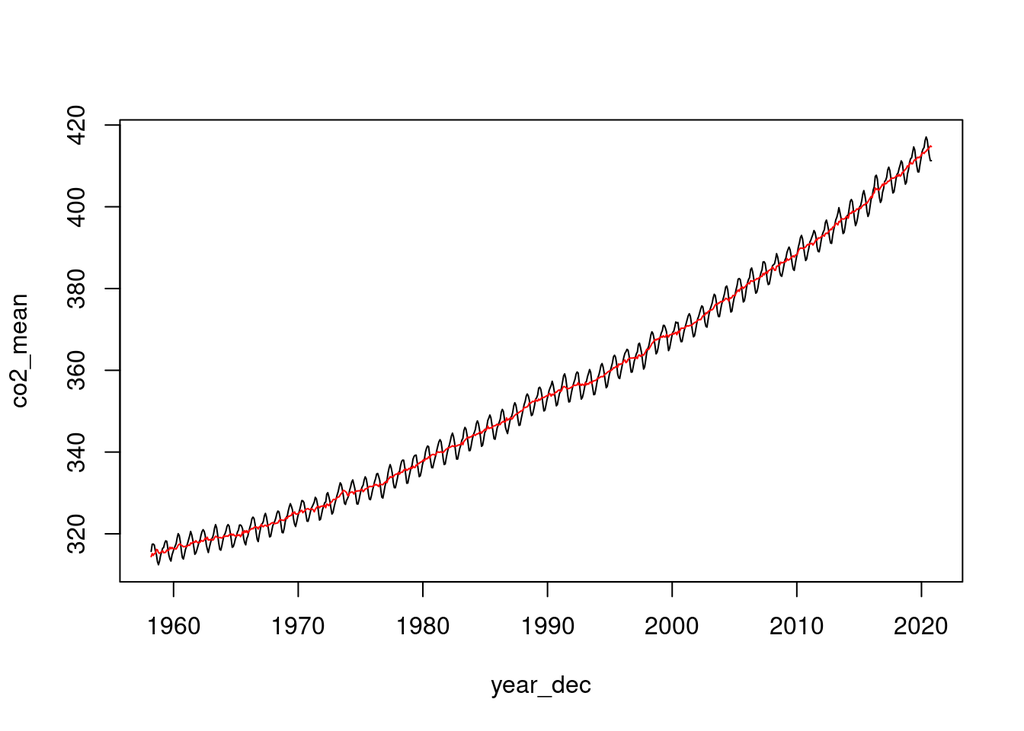

```r
plot(co2_mean ~ year_dec, co2m, type = 'l')
lines(co2_deseasonalized ~ year_dec, co2m, col = 'red')
```

As we see, the trend is not entirely linear, and we get serial correlation in regression residuals:

```r
co2_e = residuals(lm(co2_deseasonalized ~ year_dec, co2m))
runs.test(co2_e)
```

```
##
##  Runs Test
##
## data:  co2_e
## statistic = -26.419, runs = 15, n1 = 376, n2 = 376, n = 752, p-value <
## 2.2e-16
## alternative hypothesis: nonrandomness
```

```r
co2_ts = ts(co2m$co2_mean, frequency = 12, start = co2m$year_dec[1])
s = stl(co2_ts, s.window = 7)
names(s)
```

```
## [1] "time.series" "weights"     "call"        "win"         "deg"
## [6] "jump"        "inner"       "outer"
```

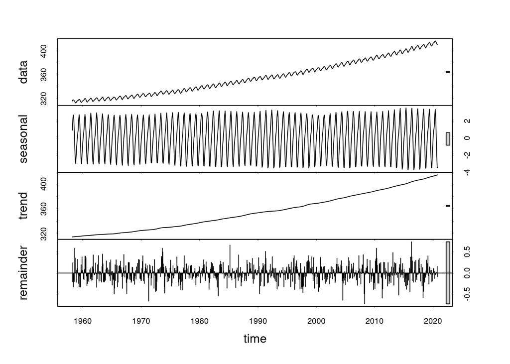

```r
plot(s)
```

We can get access to the individual components by

```r
head(s$time.series) # head() selects the first six records:
```

```
##        seasonal    trend  remainder
## [1,]  0.9321919 314.9760 -0.2082041
## [2,]  2.1678887 315.0409  0.2412158
## [3,]  2.7312465 315.1058 -0.3270252
## [4,]  2.2795035 315.1707 -0.2101656
## [5,]  0.8268843 315.2327 -0.1995941
## [6,] -0.9477140 315.2948  0.5829564
```

and we can look for serial correlation in the `remainder` series by

```r
runs.test(s$time.series[,"remainder"])
```

```
##
##  Runs Test
##
## data:  s$time.series[, "remainder"]
## statistic = -5.5466, runs = 301, n1 = 376, n2 = 376, n = 752, p-value =
## 2.913e-08
## alternative hypothesis: nonrandomness
```

suggesting a significant temporal correlation. What else can we do? Compute the serial correlation (temporal, autocorrelation):

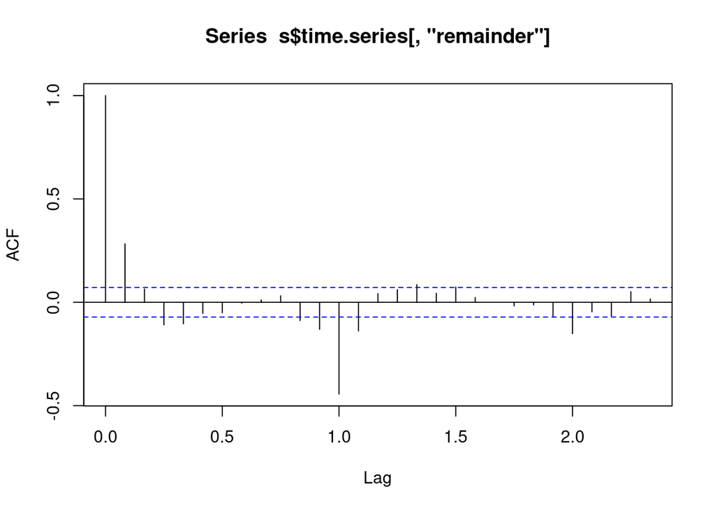

```r
acf(s$time.series[,"remainder"])
```

This reveals the (obvious, trivial) lag-0 autocorrelation of 1, but in addition the interesting, significant lag-1 autocorrelation, and no indications of further positive autocorrelation at short lags. We see significant *negative* autocorrelations at lag 12 and 24 months (at axis tics 1 = 1 year and 2 = 2 year), which might be artifacts from fitting the periodic component (i.e., a result from model misspecification, or overfitting).

So we see that this co2 time series can be decomposed in

- a smooth, gradual nearly linear trend
- a cyclic (yearly) effect, very regular but over time slightly changing
- a residual (“remainder”) that has positive autocorrelation for lag 1 (month-to-month)

## Spatial autocorrelation

We will use the temperature data of STRbook:

```r
data("NOAA_df_1990", package = "STRbook")
library(dplyr)
Tmax <- filter(NOAA_df_1990,        # subset the data
              proc == "Tmax" &      # only max temperature
              date == "1993-07-06") # temperature for single time step
```

```r
library(sf)
Tmax.sf = st_as_sf(Tmax, coords = c("lon", "lat"), crs = 'OGC:CRS84',
                                    remove = FALSE)
library(gstat)
v = variogram(z~1, Tmax.sf)
```

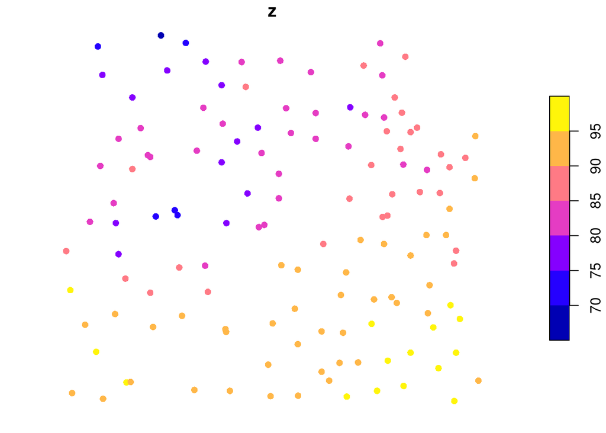

```r
plot(Tmax.sf["z"], pch = 16)
```

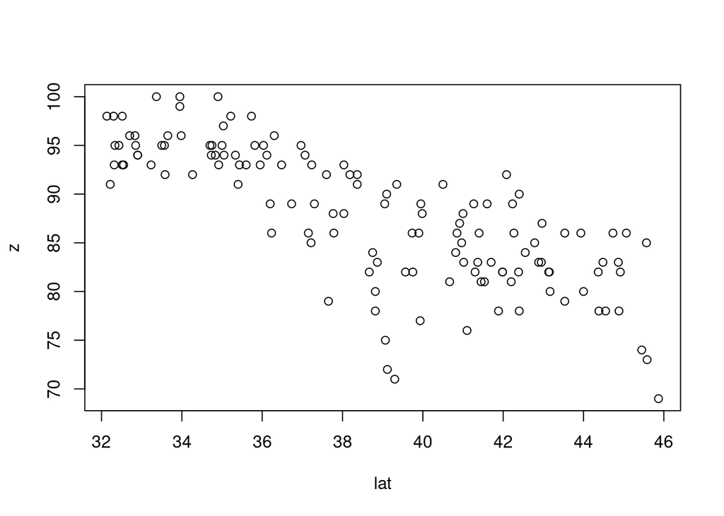

```r
plot(z~lat, Tmax.sf)
```

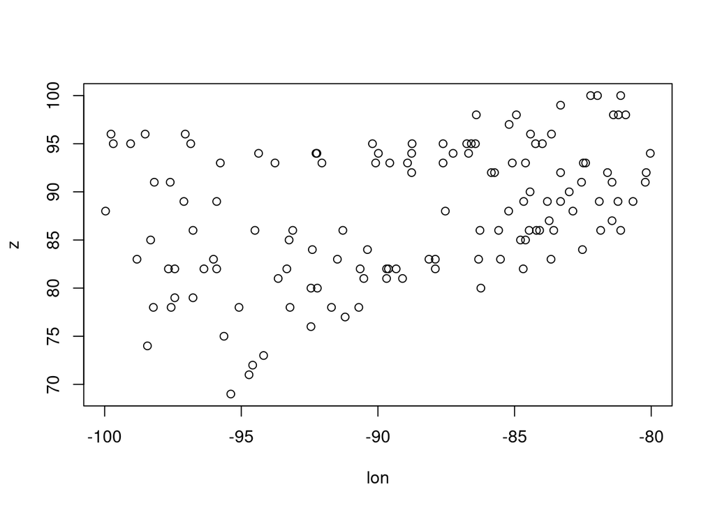

```r
plot(z~lon, Tmax.sf)
```

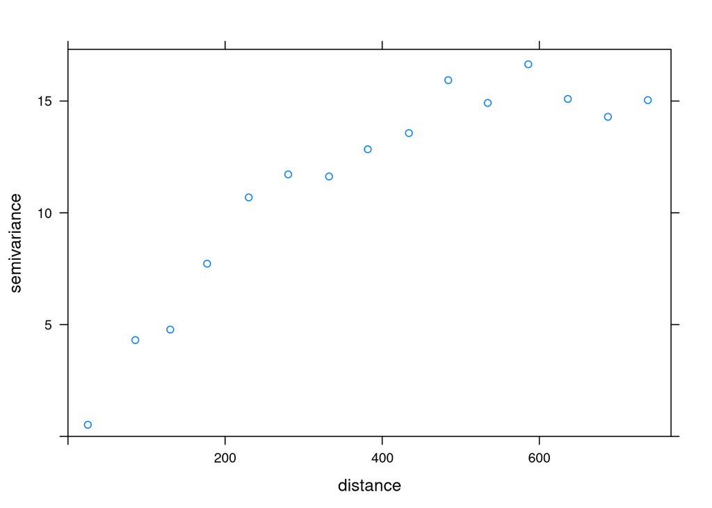

```r
v = variogram(z~lon+lat, Tmax.sf)
plot(v)
```

## Temporal correlation in Tmax:

```r
Tmax.3804 <- filter(NOAA_df_1990,      # subset the data
              proc == "Tmax",        # only max temperature
                          id == 3804) %>%        # single station
    select(z, date) %>%
    arrange(date)
Tmax.ts = ts(Tmax.3804$z, frequency = 365.25, start = 1990)
```

So, we can look at temporal autocorrelation (for this station) with

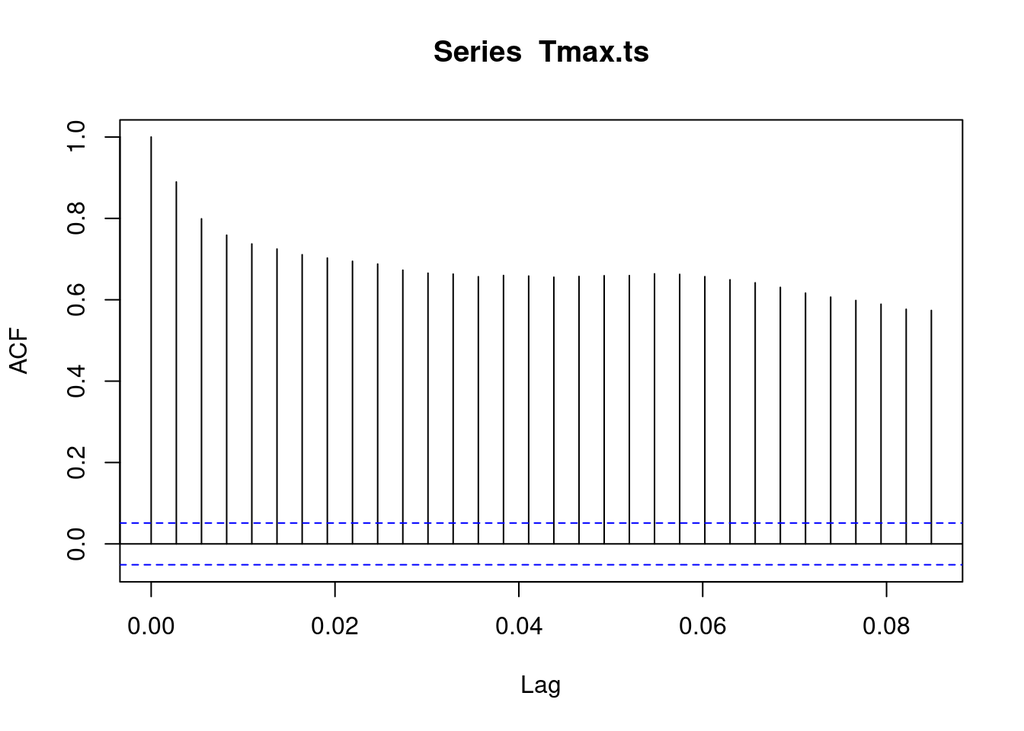

```r
acf(Tmax.ts)
```

But what is it: a trend? a seasonal effect? Model misspecification?

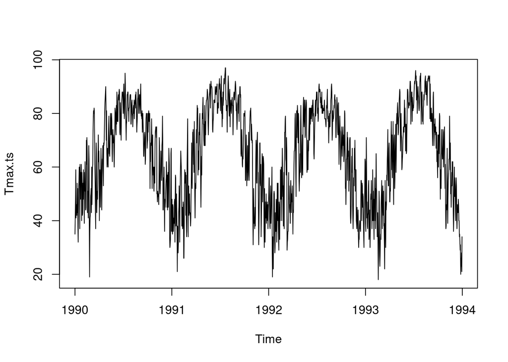

```r
plot(Tmax.ts)
```

indicates there is a strong seasonal effect. Using e.g. `stl` to decompose:

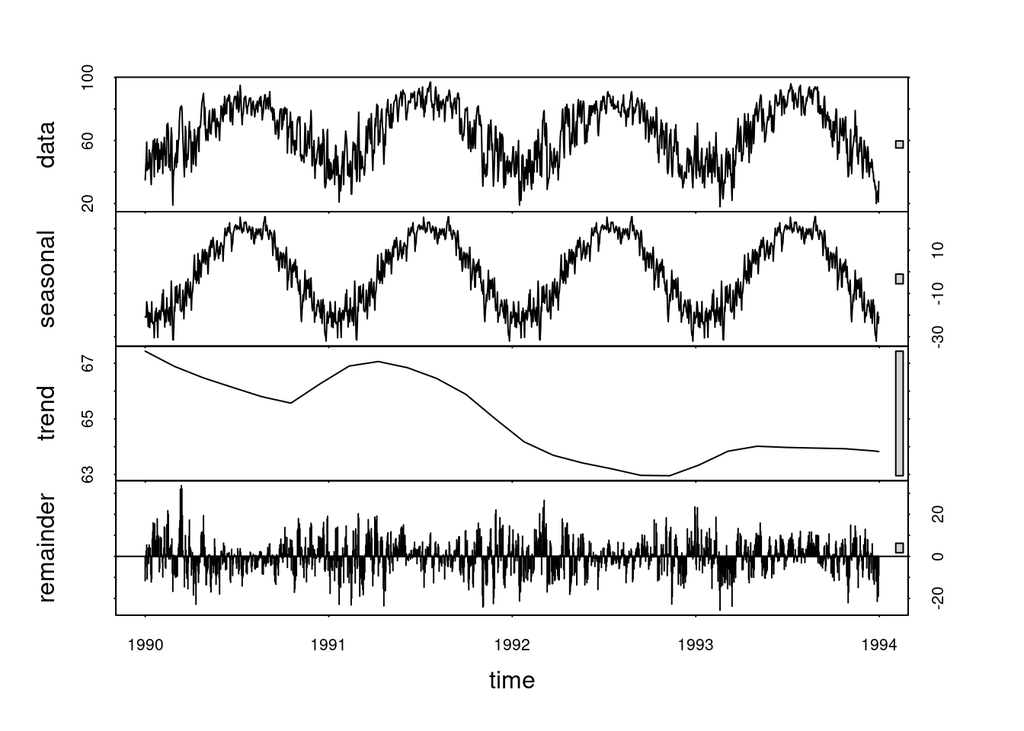

```r
Tmax.stl = stl(Tmax.ts, s.window = 30)
plot(Tmax.stl)
```

We can now look at the autocorrelation of the remainder:

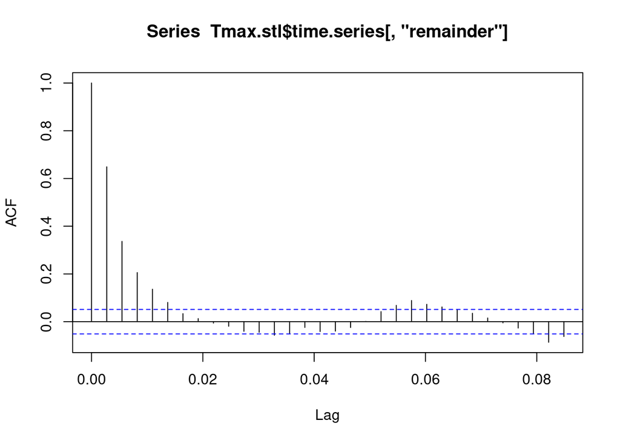

```r
acf(Tmax.stl$time.series[,"remainder"])
```

Where we see

- (the trivial autocorrelation 1 for lag 0)
- a positive autocorrelation for lags 1…5
- some weak oscillation that doesn’t really extend beyond the significance bars (blue dashed lines)

## Summing up

- for spatial correlation, we typically focus on variograms or covariances
- variograms are inverted covariances: $\gamma(h) = C(0) - C(h)$
- for time series we’re used to look at autocorrelations
- (auto) correlations are covariances, scaled to $[-1,1]$.